# Plate-forme de force : de l’acquisition aux traitements

Louis GERVILLE-RÉACHE

L’objectif de ce document est de décrire la démarche d’acquisition puis de formatage des données d’une plate-forme de force pour pouvoir ensuite les traiter dans R Studio en proposant quelques exemples de visualisation et de traitement des données.

# Description de l’outil de mesure

Une plateforme de force est une plaque rigide équipée de capteurs de force sous la surface de la plateforme. Ces capteurs mesurent les forces appliquées dans trois directions orthogonales. Elle mesure aussi les moments de force autour des axes de la plateforme.

### Forces (Newton)

¤ Force verticale (Fz) : Elle est généralement la plus importante en amplitude et représente le poids du sujet et les forces dynamiques lors des mouvements tels que la marche, la course ou le saut.

¤ Force antéro-postérieure (Fx) : Elle est liée aux forces de freinage et de propulsion. Par exemple, lors de la marche, il y a une force de freinage au contact initial et une force de propulsion au moment du décollement du pied.

¤ Force médio-latérale (Fy) : Elle reflète les forces latérales et est importante pour l’équilibre et la stabilité latérale.

### Moments (Newton mètre)

¤ Moment autour de l’axe X (Mx) : Produit par les forces dans les directions Y et Z. Ce moment est crucial pour comprendre les rotations avant-arrière de la plateforme.

¤ Moment autour de l’axe Y (My) : Produit par les forces dans les directions X et Z. Ce moment informe sur les rotations latérales de la plateforme.

¤ Moment autour de l’axe Z (Mz) : Produit par les forces dans les directions X et Y. Ce moment est souvent associé aux mouvements de torsion sur la plateforme.

# Acquisition des données

¤ Allumez la plate-forme de force qui va être utilisée pour l’enregistrement.

¤ Ouvrez le logiciel AMTINetforce sur l’ordinateur pilote.

¤ Dans l’onglet DataFolder, cliquez sur “Select Data Folder” pour choisir le dossier dans lequel l’acquisition sera enregistrée.

¤ Dans l’onglet Settings, cliquez sur “Acquisition Settings” pour modifier les paramètres de l’enregistrement (durée et fréquence).

¤ Cliquez sur Start puis sur Tare pour démarrer l’enregistrement.

¤ Cliquez sur Stop pour arrêter l’enregistrement.

¤ Dans l’onglet File, cliquez sur “Export Data File” pour enregistrer les données au format .txt dans le dossier préalablement choisi.

# Recueil des données

Il s’agit ici de formater les données brutes pour les rendre utilisables/traitables dans R.

```r
# Récupération des données
T1 <- read.csv("données brutes.txt", header = FALSE) # Pensez à renommer le nom du fichier

# Retrait des lignes parasites
T2 <- T1[-c(1, 2, 3), ]

# Labellisation des variables
colnames(T2) <- c("Fx (N)", "Fy (N)", "Fz (N)", "Mx (N.s)", "My (N.s)", "Mz (N.s)")

# Mise au bon format des données numériques
T2$`Fx (N)` <- as.numeric(T2$`Fx (N)`)
T2$`Fy (N)` <- as.numeric(T2$`Fy (N)`)
T2$`Fz (N)` <- as.numeric(T2$`Fz (N)`)
T2$`Mx (N.s)` <- as.numeric(T2$`Mx (N.s)`)
T2$`My (N.s)` <- as.numeric(T2$`My (N.s)`)
T2$`Mz (N.s)` <- as.numeric(T2$`Mz (N.s)`)

# Saisie des paramètres de l'enregistrement
Hz <- 50 # Fréquence d'enregistrement en Hertz
D <- 20  # Durée de l'enregistrement en seconde

# Création de la variable de temps
T2$`Time (s)`<- seq(1/Hz, D, by = 1/Hz)

# Aperçu de la table finale
mon_service <- T2
head(mon_service)
```

```
##     Fx (N)   Fy (N)   Fz (N)  Mx (N.s)  My (N.s) Mz (N.s) Time (s)
## 4  0.46378 16.19922 743.9375 -16.60254 -23.29102  0.92892     0.02
## 5 -0.43695 15.50146 739.9062 -17.61719 -22.45801  1.14783     0.04
## 6 -0.35854 14.05176 738.0938 -18.58008 -21.56836  1.30200     0.06
## 7 -1.12396 11.99316 739.6250 -20.24316 -21.24609  1.21832     0.08
## 8 -0.35333  9.44678 745.1875 -21.78906 -20.83398  1.40454     0.10
## 9 -0.37981  7.83472 751.1250 -23.09473 -20.24219  1.13269     0.12
```

```r
# Résumé statistique des données
summary(mon_service)
```

```
##      Fx (N)             Fy (N)             Fz (N)           Mx (N.s)
##  Min.   : -8.6187   Min.   :-27.2324   Min.   : -2.208   Min.   :-67.8320
##  1st Qu.: -0.7928   1st Qu.: -0.3320   1st Qu.:711.945   1st Qu.:-48.2617
##  Median : -0.2088   Median :  0.2013   Median :749.969   Median :-43.5488
##  Mean   :  4.1816   Mean   :  2.8816   Mean   :572.106   Mean   :-34.8396
##  3rd Qu.:  0.2879   3rd Qu.:  1.0225   3rd Qu.:751.594   3rd Qu.: -0.3828
##  Max.   :249.2109   Max.   :161.6484   Max.   :841.312   Max.   : 13.4214
##     My (N.s)          Mz (N.s)            Time (s)
##  Min.   :-80.027   Min.   :-1.957150   Min.   : 0.020
##  1st Qu.: -3.933   1st Qu.: 0.000078   1st Qu.: 5.015
##  Median : -0.250   Median : 0.338890   Median :10.010
##  Mean   : -2.988   Mean   : 0.407329   Mean   :10.010
##  3rd Qu.:  2.196   3rd Qu.: 0.545230   3rd Qu.:15.005
##  Max.   : 14.505   Max.   : 9.312010   Max.   :20.000
```

# Exemples de visualisation

### Cas d’une personne debout et immobile sur la plateforme puis qui s’en va

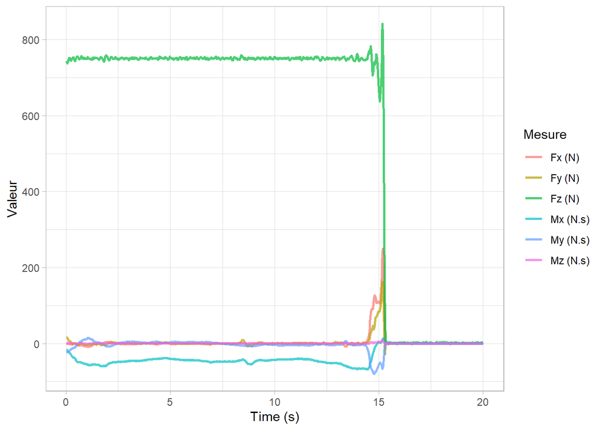

```r
library(tidyr)

mon_service_f_m <- mon_service |>
  tidyr::pivot_longer(cols = -`Time (s)`, names_to = "Mesure", values_to = "Valeur")

library(ggplot2)
ggplot(mon_service_f_m, aes(x = `Time (s)`, y = Valeur)) +
  geom_line(linewidth = 1, aes(color = Mesure), alpha = 0.7) +
  theme_light()
```

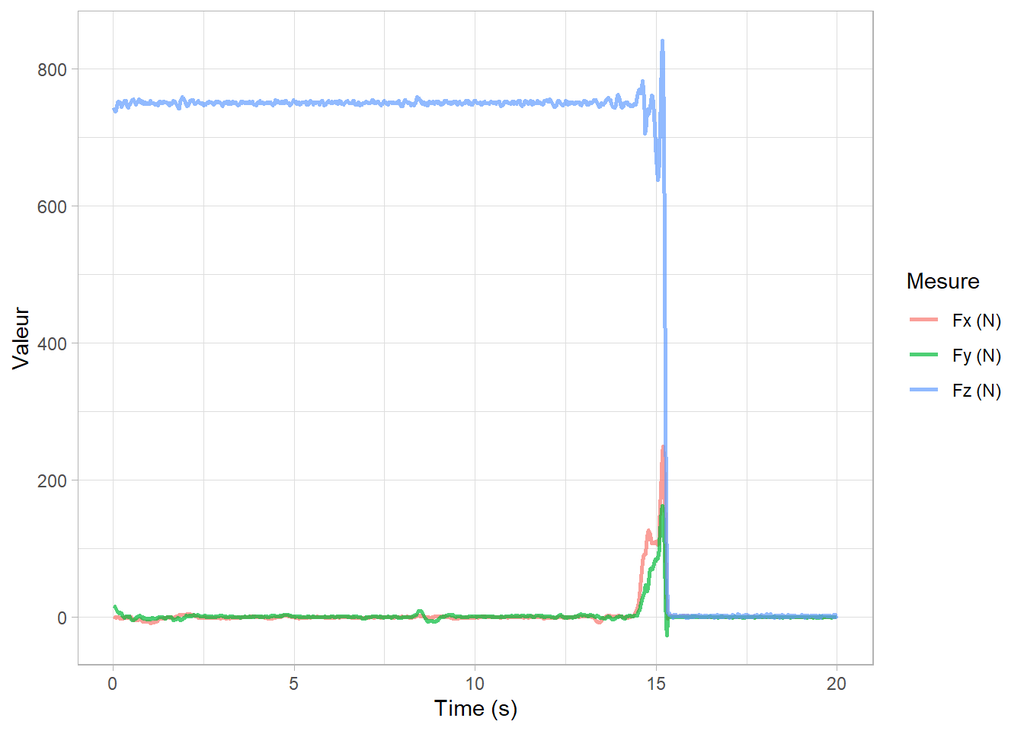

```r
mon_service_f <- subset(mon_service_f_m, Mesure == "Fx (N)" | Mesure == "Fy (N)" | Mesure == "Fz (N)")

mon_service_m <- subset(mon_service_f_m, Mesure == "Mx (N.s)" | Mesure == "My (N.s)" | Mesure == "Mz (N.s)")


ggplot(mon_service_f, aes(x = `Time (s)`, y = Valeur)) +
  geom_line(linewidth = 1, aes(color = Mesure), alpha = 0.7) +
  theme_light()
```

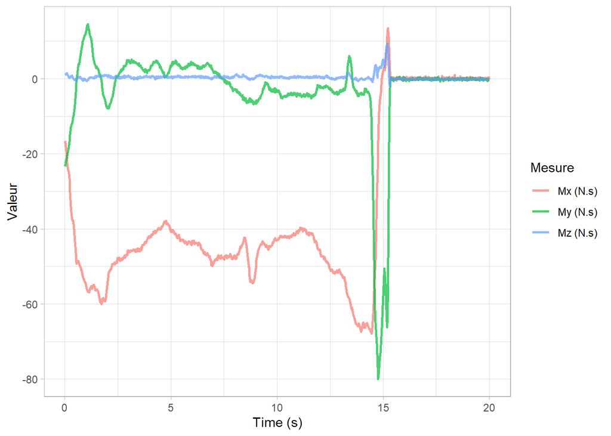

```r
ggplot(mon_service_m, aes(x = `Time (s)`, y = Valeur)) +
  geom_line(linewidth = 1, aes(color = Mesure), alpha = 0.7) +
  theme_light()
```

Uniquement dans le cas où vous êtes statique (ou quasiment statique) sur la plate-forme, vous pouvez retrouvez les positions de votre centre d’inertie projetées sur la plate-forme durant l’enregistrement grâce aux formules ci-dessous.

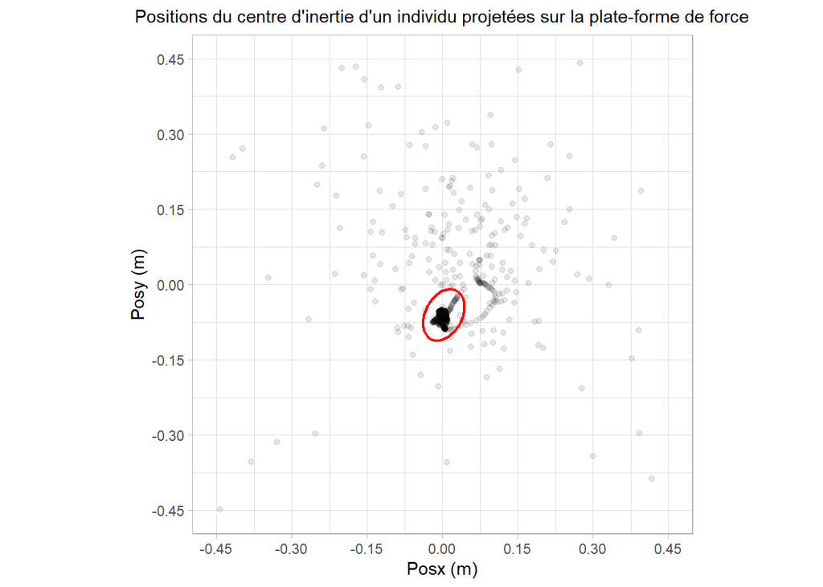

```r
mon_service$`Posy (m)` <- (T2$Fz*T2$Mx - T2$Fx*T2$Mz)/(T2$Fx^2 + T2$Fy^2 + T2$Fz^2)

mon_service$`Posx (m)` <- (T2$Fy*T2$Mz - T2$Fz*T2$My)/(T2$Fx^2 + T2$Fy^2 + T2$Fz^2)

ggplot(mon_service, aes(x = `Posx (m)`, y = `Posy (m)`))+
  geom_point(alpha = 0.1, size = 1.5) +
  stat_ellipse(level = 0.95, color = "red", linewidth = 0.8) +
  scale_x_continuous(
    breaks = c(-0.45, -0.30, -0.15, 0, 0.15, 0.30, 0.45),
    limits = c(-0.4525, 0.4525)) +
  scale_y_continuous(
    breaks = c(-0.45, -0.30, -0.15, 0, 0.15, 0.30, 0.45),
    limits = c(-0.4525, 0.4525)) +
  coord_fixed(1) +
  theme_light() +
  labs(title = "Positions du centre d'inertie d'un individu projetées sur la plate-forme de force") +
  theme(plot.title = element_text(size = 11, hjust=0.5))
```

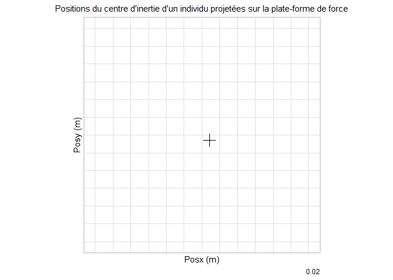

```r
library(gganimate)

g<-ggplot(mon_service, aes(x = `Posx (m)`, y = `Posy (m)`)) +
  geom_point(alpha = 1, size = 5, shape = 3) +
  scale_x_continuous(
    breaks = c(-0.45, -0.30, -0.15, 0, 0.15, 0.30, 0.45),
    limits = c(-0.4525, 0.4525)) +
  scale_y_continuous(
    breaks = c(-0.45, -0.30,-0.15, 0, 0.15, 0.30, 0.45),
    limits = c(-0.4525, 0.4525)) +
  coord_fixed(1) +
  theme_light() +
  labs(title = "Positions du centre d'inertie d'un individu projetées sur la plate-forme de force",
       caption = "{frame_time}") +
  theme(plot.title = element_text(size = 11, hjust = 0.5)) +
  transition_time(`Time (s)`)


animate(g,
        start_pause = 25, end_pause = 50,
        duration = 23,
        fps = 25
)
```